# Assignment 6: Visualization - Aesthetic Mapping

*How to do it?*:

- Open the Rmarkdown file of this assignment (link) in Rstudio.
- Right under each **question**, insert a code chunk (you can use the hotkey `Ctrl + Alt + I` to add a code chunk) and code the solution for the question.
- `Knit` the rmarkdown file (hotkey: `Ctrl + Alt + K`) to export an html.
- Publish the html file to your Githiub Page.

*Submission*: Submit the link on Github of the assignment to Canvas.

### Questionssss on Your Selected Data

```r
library(tidyverse)
library(ggplot2)
library(lubridate)
```

Choose a dataset and produce the following types of plots and comment on each plot. Plots should be meaningful. If you use the data we used in class, make sure the plots are not the same as the ones in the slides.

```r
titanic_data <- read_csv("titanic.csv")
```

```r
spec(titanic_data)
# Examine the data to pull out the types of variables

titanic_data
```

```
## # A tibble: 891 x 12
##    PassengerId Survived Pclass Name   Sex     Age SibSp Parch Ticket  Fare Cabin
##          <dbl>    <dbl>  <dbl> <chr>  <chr> <dbl> <dbl> <dbl> <chr>  <dbl> <chr>
##  1           1        0      3 Braun~ male     22     1     0 A/5 2~  7.25 <NA>
##  2           2        1      1 Cumin~ fema~    38     1     0 PC 17~ 71.3  C85
##  3           3        1      3 Heikk~ fema~    26     0     0 STON/~  7.92 <NA>
##  4           4        1      1 Futre~ fema~    35     1     0 113803 53.1  C123
##  5           5        0      3 Allen~ male     35     0     0 373450  8.05 <NA>
##  6           6        0      3 Moran~ male     NA     0     0 330877  8.46 <NA>
##  7           7        0      1 McCar~ male     54     0     0 17463  51.9  E46
##  8           8        0      3 Palss~ male      2     3     1 349909 21.1  <NA>
##  9           9        1      3 Johns~ fema~    27     0     2 347742 11.1  <NA>
## 10          10        1      2 Nasse~ fema~    14     1     0 237736 30.1  <NA>
## # ... with 881 more rows, and 1 more variable: Embarked <chr>
```

1. For one continuous variable:
- Density

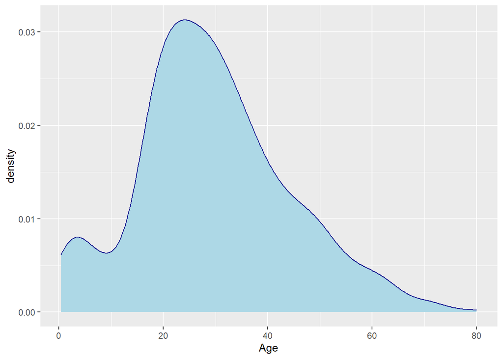

```r
ggplot(titanic_data, aes(x = Age)) +
  geom_density(color = "darkblue", fill = "lightblue")
```

- Histogram

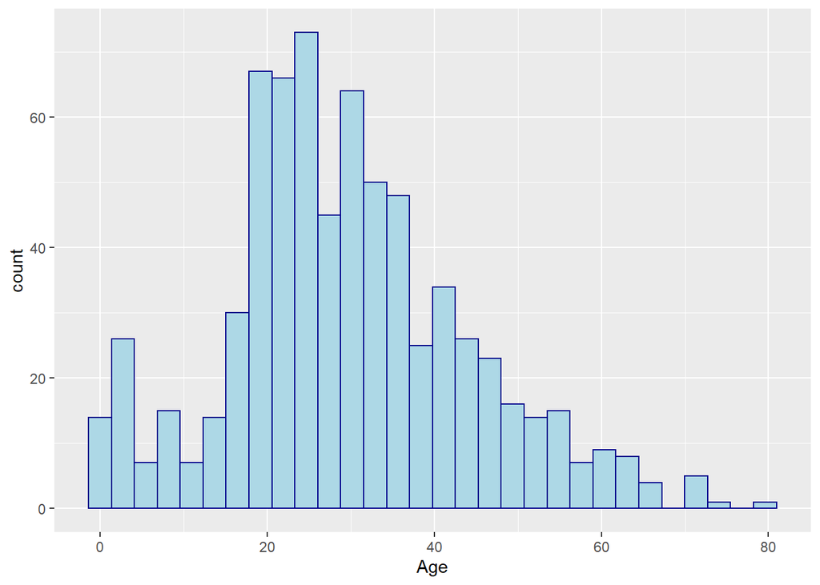

```r
ggplot(titanic_data, aes(x = Age)) +
geom_histogram(color = "darkblue", fill = "lightblue")
```

- Boxplot

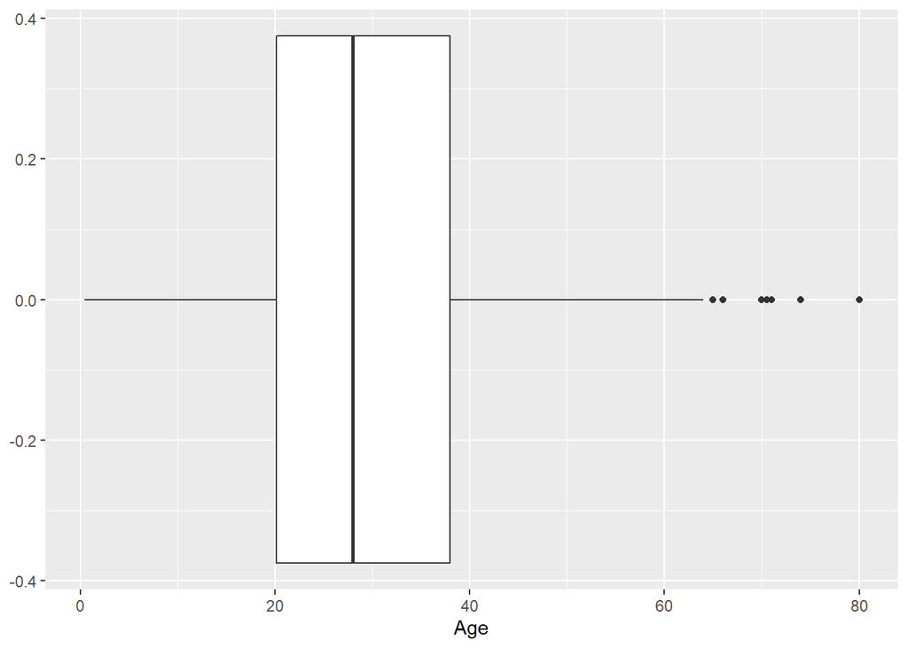

```r
ggplot(titanic_data, aes(x = Age)) +
geom_boxplot()
```

2. For one categorical variable
- Barplot

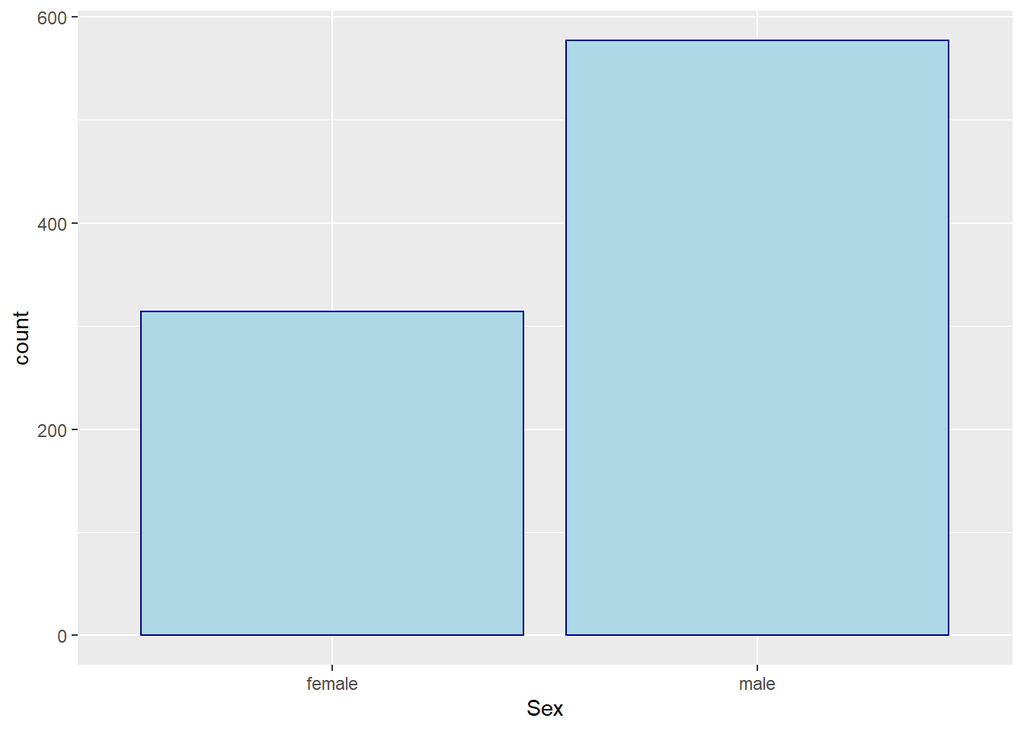

```r
titanic_data %>%  ggplot()+
  geom_bar(mapping = aes( x = Sex), color = "darkblue", fill = "lightblue")
```

3. For one two continuous variables
- Scatter Plot

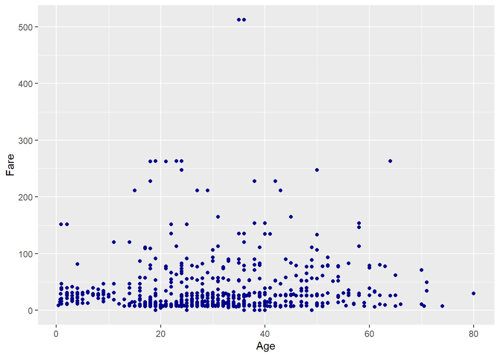

```r
# Use age and fare for this question



titanic_data %>% ggplot() +
  geom_point(mapping = aes(x= Age, y = Fare), color = "darkblue", fill = "lightblue")
```

- Line Plot

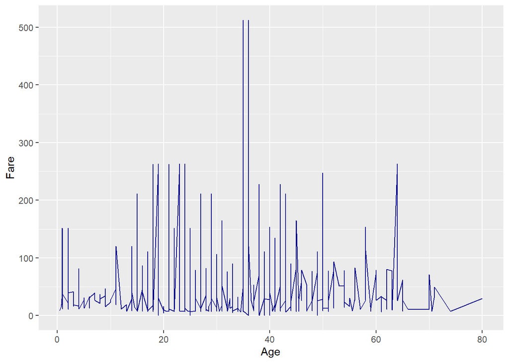

```r
titanic_data %>% ggplot() +
  geom_line(mapping = aes( x = Age, y = Fare), color = "darkblue", fill = "lightblue")
```

- Smooth Plot

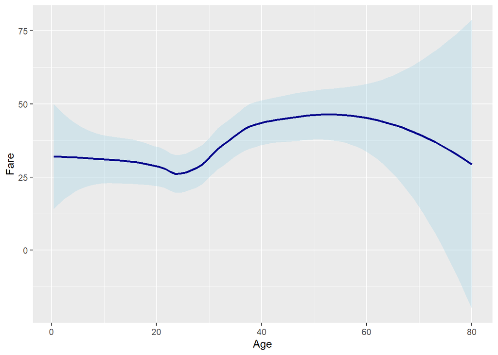

```r
titanic_data %>% ggplot() +
  geom_smooth(mapping = aes(x = Age, y = Fare), color = "darkblue", fill = "lightblue")
```

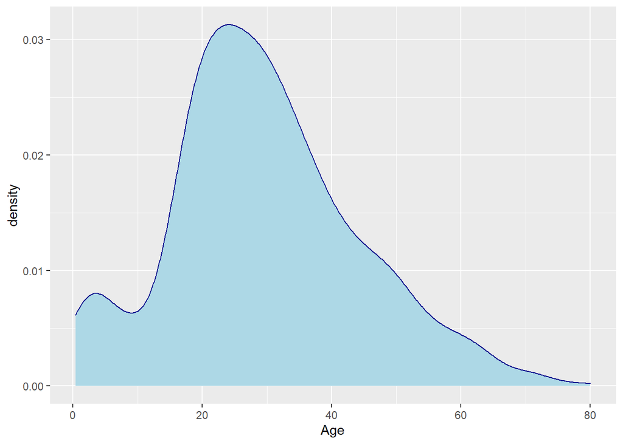

```r
titanic_data %>% ggplot()+
  geom_density(mapping = aes(x = Age, color = Survived), color = "darkblue", fill = "lightblue")
```

- BoxPlot

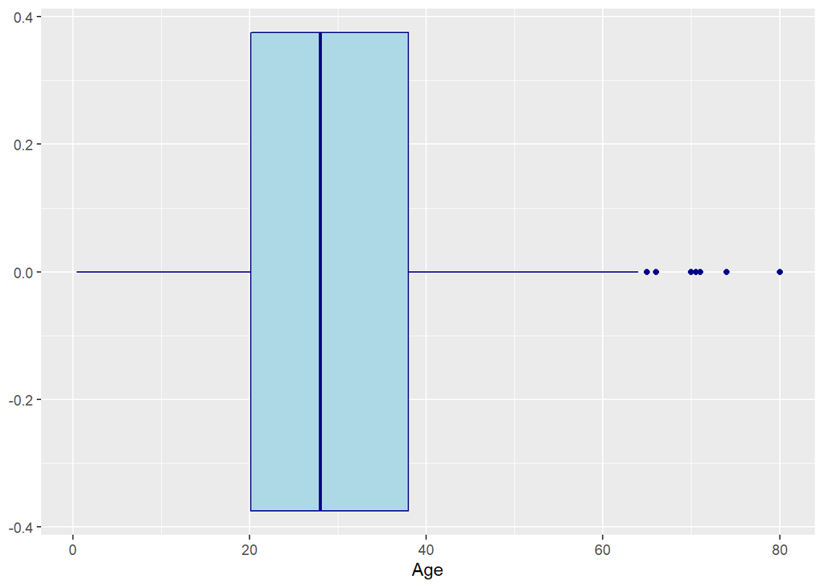

```r
titanic_data %>% ggplot()+
  geom_boxplot(mapping = aes(x = Age, color = Survived), color = "darkblue", fill = "lightblue")
```

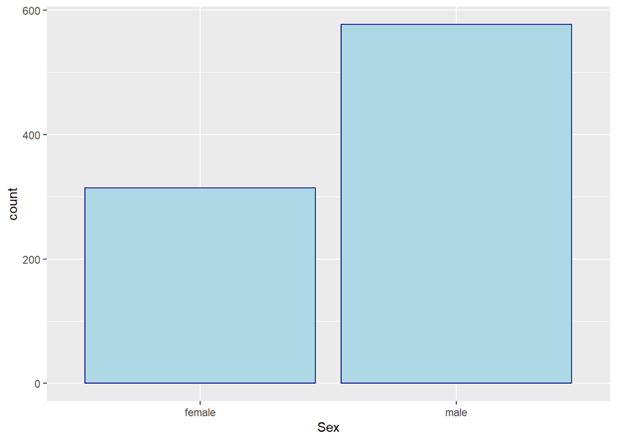

```r
titanic_data %>% ggplot()+
  geom_bar(mapping = aes(x = Sex, color = Survived), color = "darkblue", fill = "lightblue")
```

### Questions on Covid Vaccination Data

In this section of questions, we will use the covid vaccination data for the US. The data and data dictionary can be found at the below link:

- [Data](https://raw.githubusercontent.com/govex/COVID-19/master/data_tables/vaccine_data/us_data/time_series/vaccine_data_us_timeline.csv)
- [Data Dictionary](https://github.com/govex/COVID-19/blob/master/data_tables/vaccine_data/us_data/data_dictionary.csv)

```r
library(tidyverse)
df <- read_csv('https://raw.githubusercontent.com/govex/COVID-19/master/data_tables/vaccine_data/us_data/time_series/vaccine_data_us_timeline.csv')

df
```

```
## # A tibble: 107,464 x 13
##    Province_State Date       Vaccine_Type  FIPS Country_Region   Lat Long_
##    <chr>          <date>     <chr>        <dbl> <chr>          <dbl> <dbl>
##  1 Alabama        2020-12-10 All              1 US              32.3 -86.9
##  2 Alabama        2020-12-10 Moderna          1 US              32.3 -86.9
##  3 Alabama        2020-12-10 Pfizer           1 US              32.3 -86.9
##  4 Alabama        2020-12-11 All              1 US              32.3 -86.9
##  5 Alabama        2020-12-11 Moderna          1 US              32.3 -86.9
##  6 Alabama        2020-12-11 Pfizer           1 US              32.3 -86.9
##  7 Alabama        2020-12-12 All              1 US              32.3 -86.9
##  8 Alabama        2020-12-12 Moderna          1 US              32.3 -86.9
##  9 Alabama        2020-12-12 Pfizer           1 US              32.3 -86.9
## 10 Alabama        2020-12-13 All              1 US              32.3 -86.9
## # ... with 107,454 more rows, and 6 more variables: Doses_alloc <dbl>,
## #   Doses_shipped <dbl>, Doses_admin <dbl>, Stage_One_Doses <dbl>,
## #   Stage_Two_Doses <dbl>, Combined_Key <chr>
```

1. `Geom_point` makes scatter plots, which plot two numeric (or Date) variables. A third categorical variable is often brought in for color. For example, we can compare different vaccine types in Rhode Island by

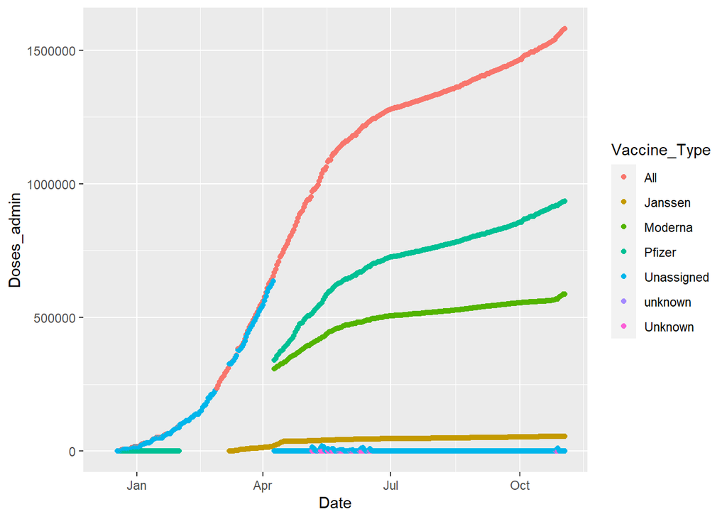

```r
df %>% filter(Province_State=='Rhode Island') %>% ggplot()+geom_point(mapping = aes(x = Date, y = Doses_admin, color = Vaccine_Type))
```

Do the follows.

- Use `geom_point` to compare the the Moderna and Pfizer vaccine administered in California

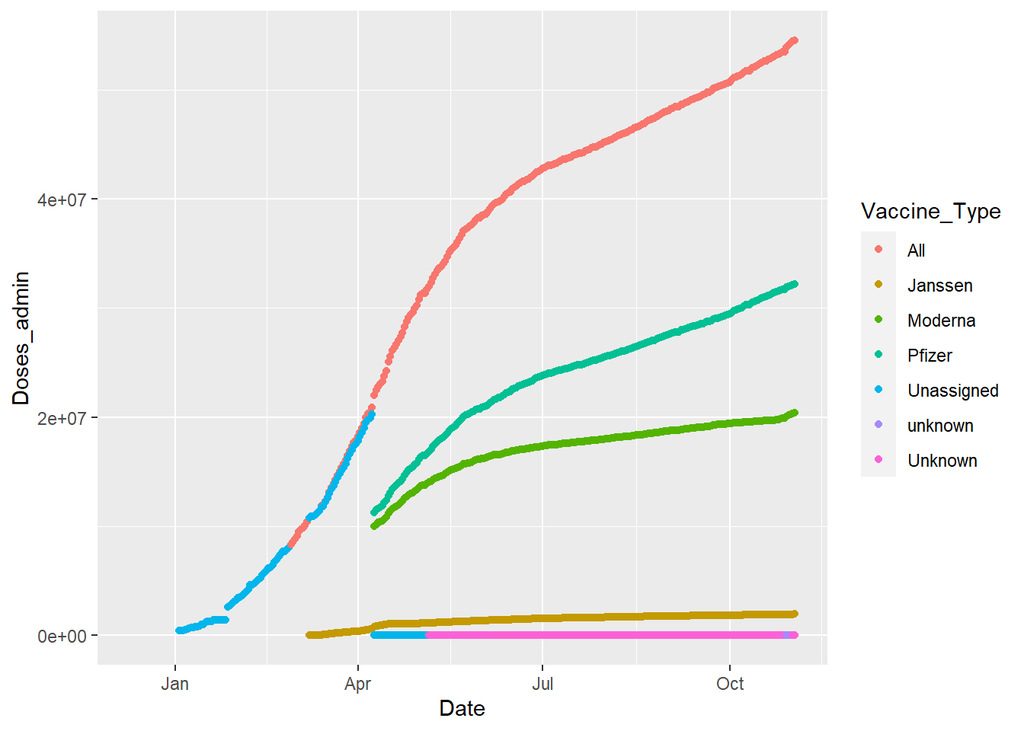

```r
df %>% filter(Province_State=='California') %>% ggplot()+
  geom_point(mapping = aes(x = Date, y = Doses_admin, color =Vaccine_Type))
```

- Use `geom_point` to compare the total vaccine administered in Rhode Island and Massachusetts

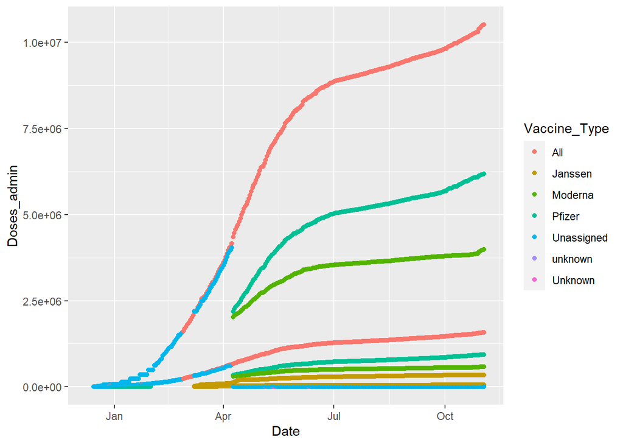

```r
df %>% filter(Province_State=='Rhode Island' | Province_State =='Massachusetts') %>% ggplot()+
  geom_point(mapping = aes(x = Date, y = Doses_admin, color =Vaccine_Type))
```

- Change `geom_point` to `geom_line` in the above codes to have the corresponding line plots.

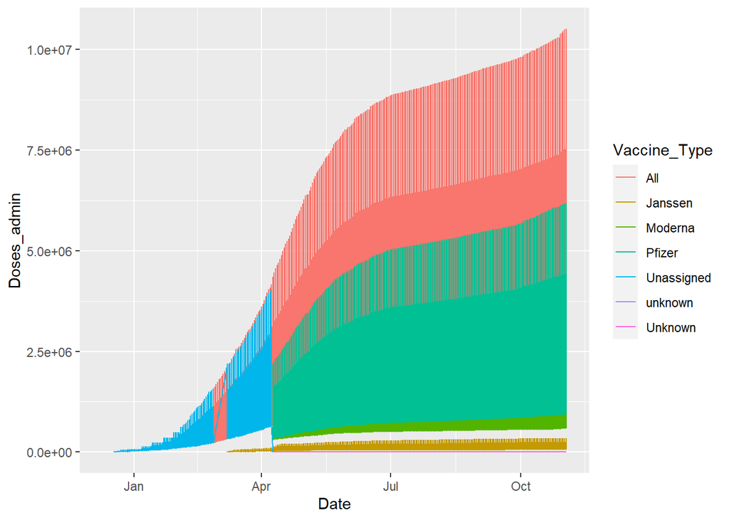

```r
df %>% filter(Province_State=='Rhode Island' | Province_State =='Massachusetts') %>% ggplot()+
  geom_line(mapping = aes(x = Date, y = Doses_admin, color =Vaccine_Type))
```

2. Sometime we need to do some calculations on the data before plotting. For example, to compare the popularity of two vaccine `Moderna` and `Pfizer` by date, we can use.

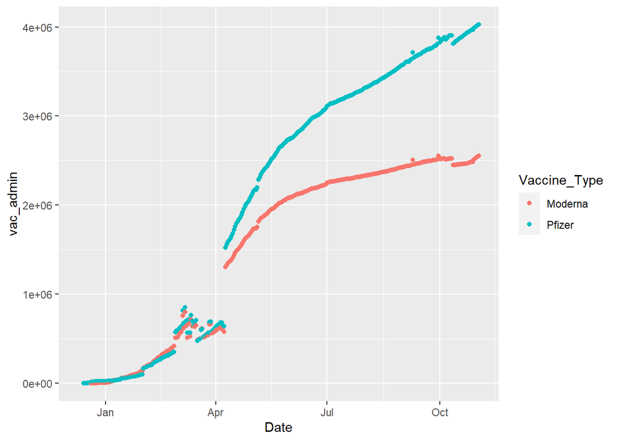

```r
# Create a dataset recording these two vaccine administered by date
d1 <- df %>% filter(Vaccine_Type==c('Moderna','Pfizer')) %>% group_by(Date, Vaccine_Type) %>% summarise(vac_admin=mean(Doses_admin, na.rm=TRUE))

# Plot from the newly create data
d1 %>% ggplot()+geom_point(mapping=aes(x=Date, y=vac_admin, color=Vaccine_Type))
```

Do the follows.

- Use `geom_point` to compare the popularity of all vaccines by date.

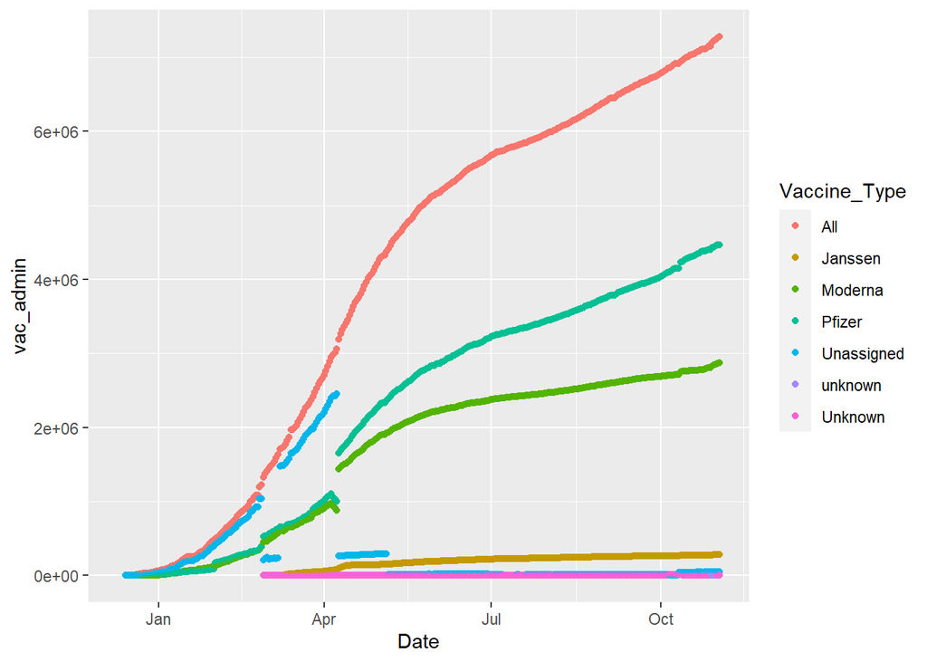

```r
# Step one: create a dataset in order to be able to plot it after.

d1 <- df %>% group_by(Date, Vaccine_Type) %>% summarise(vac_admin=mean(Doses_admin, na.rm=TRUE))



# visualization aspect:

d1 %>% ggplot()+geom_point(mapping=aes(x=Date, y=vac_admin, color=Vaccine_Type))
```

- Use `geom_line` to compare the popularity of all vaccines in New England by date.

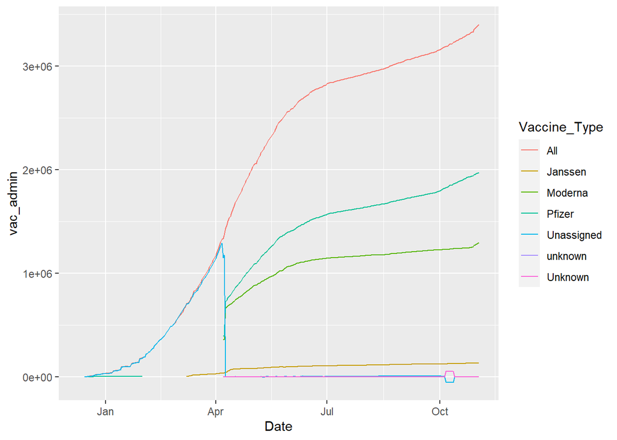

```r
d2 <- df %>% filter(Province_State %in% c('Massachusetts','Rhode Island','Conneticut','Maine','Vermont','New Hampshire')) %>% group_by(Date, Vaccine_Type) %>% summarise(vac_admin=mean(Doses_admin, na.rm=TRUE))


# Visualization aspect:

d2 %>% ggplot()+geom_line(mapping=aes(x=Date, y=vac_admin, color=Vaccine_Type))
```

- Use `geom_line` to compare the popularity of all vaccines in New England by month.

[figure not shown]

```r
df$month <- factor(month(df$Date))

d3 <- df %>% filter(Province_State %in% c('Massachusetts','Rhode Island','Conneticut','Maine','Vermont','New Hampshire')) %>% group_by(month, Vaccine_Type) %>% summarise(vac_admin=mean(Doses_admin, na.rm=TRUE))

# Visualization:

d3 %>% ggplot()+geom_line(mapping=aes(x=month, y=vac_admin, color=Vaccine_Type))
```

- Use `geom_line` to compare states in New England in term of the total vaccine administered by date.

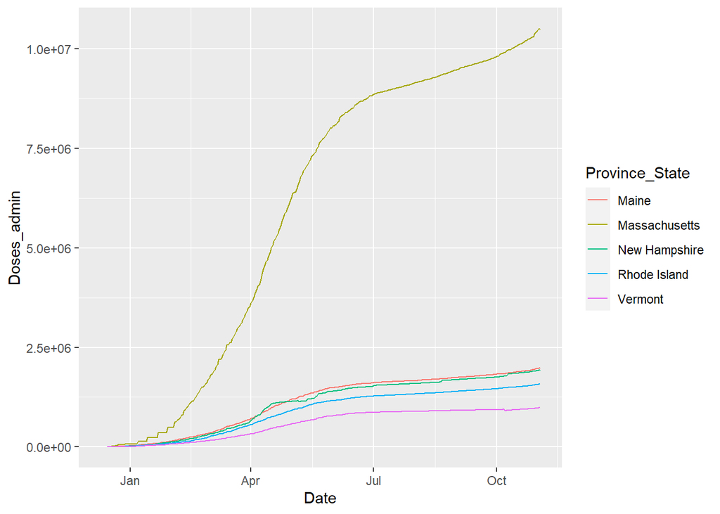

```r
df %>% filter(Province_State=='Rhode Island'|Province_State=='Massachusetts'|Province_State=='Maine' |Province_State=='Vermont'|Province_State=='New Hampshire'|Province_State=='Conneticut', Vaccine_Type=="All") %>% ggplot()+
  geom_line(mapping = aes(x = Date, y = Doses_admin, color = Province_State))
```